#Install Packages

```r
'
install.packages("dplyr")
install.packages("forecast")
install.packages("lmtest")
install.packages("orcutt")
install.packages("HoRM")
install.packages("dLagM")
install.packages("dynlm")
install.packages("MLmetrics")
install.packages("car")
install.packages("ggplot2")
install.packages("tsibble")
install.packages("tseries")
install.packages("MASS")
install.packages("TSA")
install.packages("TTR")
install.packages("aTSA")
install.packages("graphics")
install.packages("readxl")
'
```

[output not shown]

#Modules

```r
library(readxl)
library(dplyr)
library(lmtest)
library(orcutt)
library(HoRM)
library(dLagM)
library(dynlm)
library(MLmetrics)
library(car)
```

```r
library(ggplot2)
library(tsibble)
library(tseries)
library(MASS)
library(forecast)
library(TSA)
library(TTR)
library(aTSA)
library(graphics)
```

#Input Data

```r
rawdata=read.csv("D:/Kuliah/!yes/R/Semester5/MPDW/Files/Monthly-train.csv")

#head(rawdata)
#length(rawdata)

#We'll just use v2 as its own response to simplify things, and set the size of the data to 200
n=200
df=rawdata[1:n,1:2]
colnames(df)=c("Period", "Data")
df$Period=seq(1,n)
head(df)
```

```
##   Period Data
## 1      1 8000
## 2      2 2440
## 3      3 2670
## 4      4 7264
## 5      5 4210
## 6      6 5600
```

#Exploration ##DF

```r
#sum(is.na(df))
#str(df)
#dim(df)
```

##Visualize Dataset

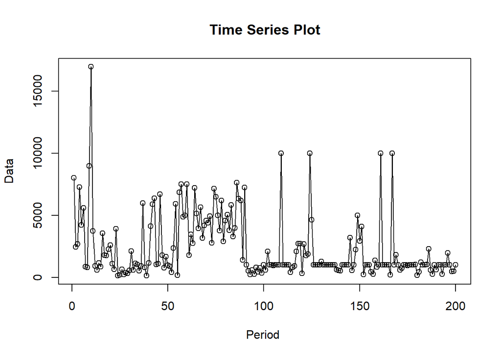

```r
data.ts=ts(df$Data, frequency = 1)
ts.plot(data.ts, xlab="Period ", ylab="Data",
        main = "Time Series Plot")
points(data.ts)
```

##Train Test Split

```r
#We'll just do 85|20 split for the dataset, as finding a stable trend for the test split is the main priority. Though the data being used is an artificial data with a meaningless input. Subjects to change neither seasonly nor having a stable trend.
temp=round(n*0.85)
train.data=df[1:temp,]
train.ts=ts(train.data$Data, frequency = 1)

temp=round(n*0.85)+1
test.data=df[temp:n,]
test.ts=ts(test.data$Data, frequency =  1)
h=length(test.ts)
```

##Visualize train test split

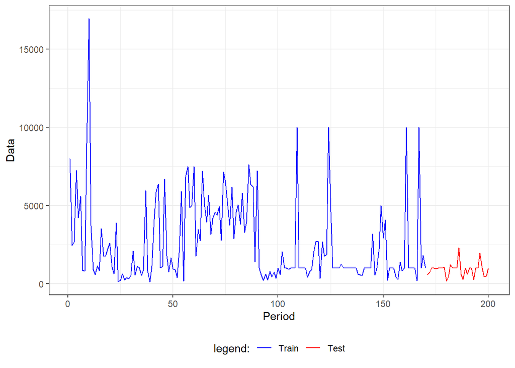

```r
#The entire dataset
#colnames(df)
ggplot() +
  geom_line(data = train.data, aes(x = Period, y = Data, col = "Train")) +
  geom_line(data = test.data, aes(x = Period, y = Data, col = "Test")) +
  scale_colour_manual(name="legend:", breaks = c("Train", "Test"),
                      values = c("blue", "red")) +
  theme_bw() + theme(legend.position = "bottom",
                     plot.caption = element_text(hjust=0.5, size=12))
```

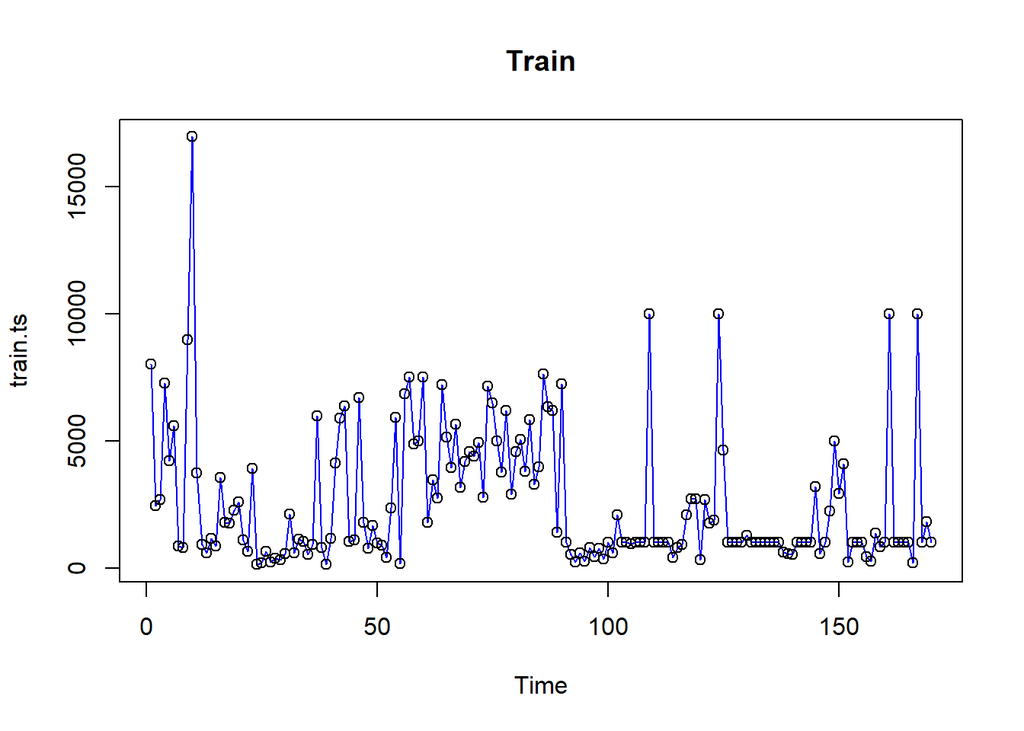

```r
#Train
plot(train.ts, col="blue",main="Train")
points(train.ts)
```

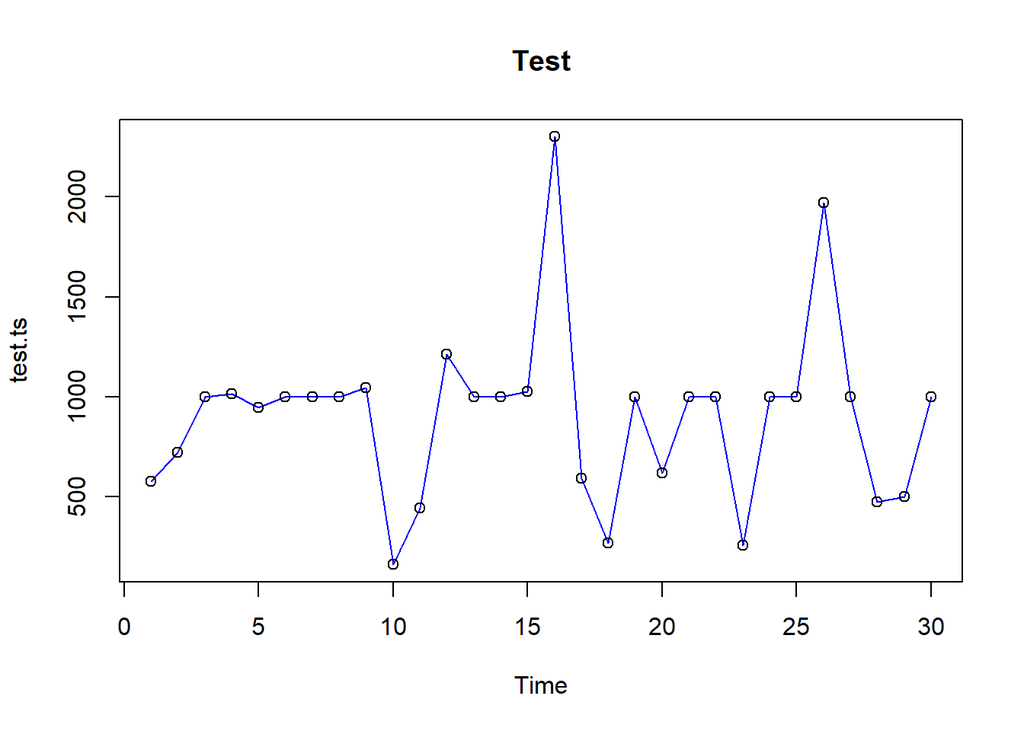

```r
#Test
plot(test.ts, col="blue",main="Test")
points(test.ts)
```

#Test for stationarity ##ACF plot

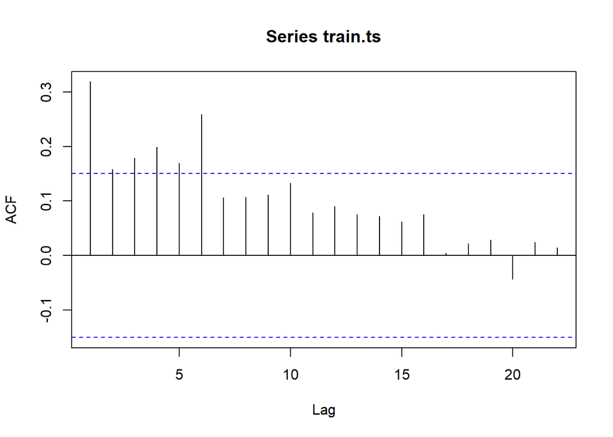

```r
#Plot ACF
acf(train.ts)
```

##ADF Test

```r
tseries::adf.test(train.ts)
```

```
##
##  Augmented Dickey-Fuller Test
##
## data:  train.ts
## Dickey-Fuller = -3.2327, Lag order = 5, p-value = 0.08468
## alternative hypothesis: stationary
```

H_0: Data tidak stasioner dalam rataan H_1 : Data stasioner dalam rataan

##Plot Box-Cox

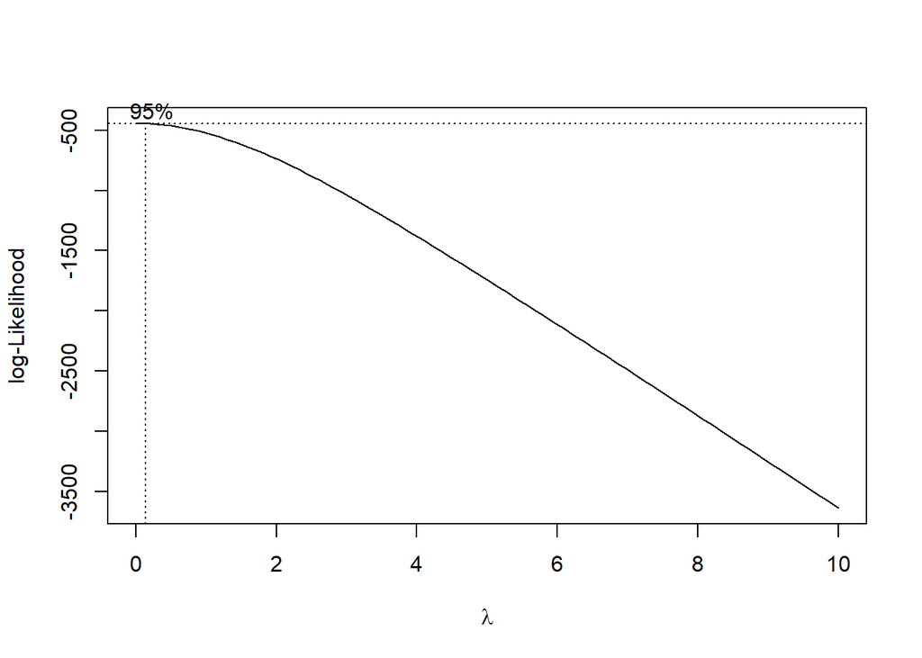

```r
index <- seq(1:length(train.ts))
bc = boxcox(train.ts~index, lambda = seq(0,10,by=1))
```

```r
#Nilai Rounded Lambda
lambda <- bc$x[which.max(bc$y)]
lambda
```

```
## [1] 0
```

```r
#SK
bc$x[bc$y > max(bc$y) - 1/2 * qchisq(.95,1)]
```

```
## [1] 0.0000000 0.1010101
```

Plot Boxcox menunjukkan nilai rounded value optimum sebesar 0 #Penanganan Ketidakstasioneran Data ##Diff function

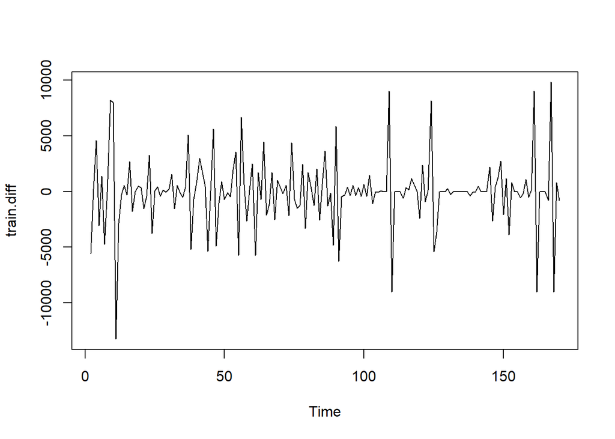

```r
train.diff<-diff(train.ts,differences = 1)
plot.ts(train.diff)
```

Berdasarkan plot data deret waktu, terlihat bahwa data sudah stasioner dalam rataan ditandai dengan data bergerak pada nilai tengah tertentu (tidak terdapat trend ataupun musiman pada data) ##Check #### Plot ACF

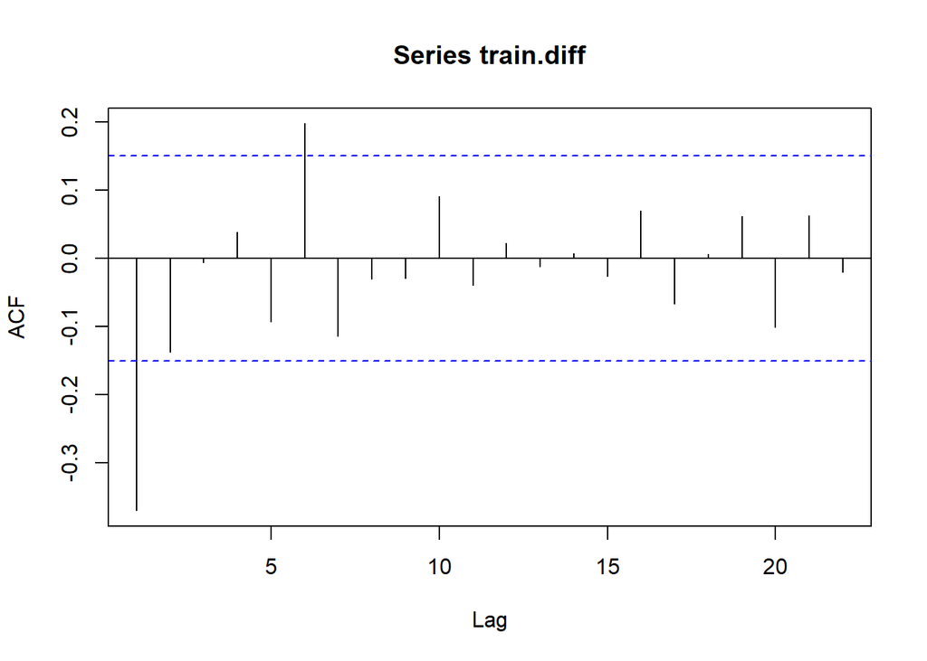

```r
acf(train.diff)
```

Berdasarkan plot tersebut, terlihat bahwa plot ACF cuts off pada lag ke 1 dan 6. Hal ini cukup menandakan data sudah stasioner dalam rataan dan ketidakstasioneran data telah berhasil tertangani.

###Uji ADF

```r
tseries::adf.test(train.diff)
```

```
##
##  Augmented Dickey-Fuller Test
##
## data:  train.diff
## Dickey-Fuller = -7.8438, Lag order = 5, p-value = 0.01
## alternative hypothesis: stationary
```

$H_0$ : Data tidak stasioner dalam rataan $H_1$ : Data stasioner dalam rataan

Dari uji ADF tersebut, didapat p-value sebesar 0.01, sehingga p val lebih kecil dari taraf nyata 5% sehingga tolak $H_0$. Cukup bukti untuk mengatakan data stasioner dalam rataan

#Get Model ## Plot ACF

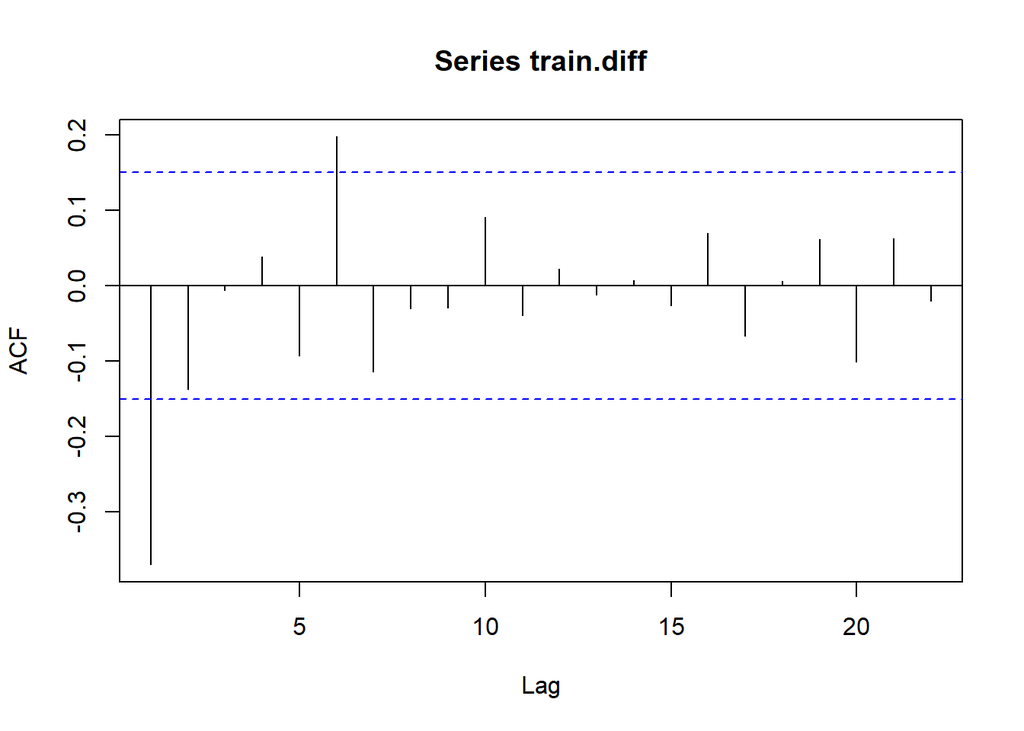

```r
acf(train.diff)
```

plot ACF cenderung *cuts off* pada lag ke 1 dan 6. Sehingga jika plot PACF dianggap *tails of*, maka model tentatifnya adalah ARIMA(0,1,1) / ARIMA(0,1,6)

##Plot PCF

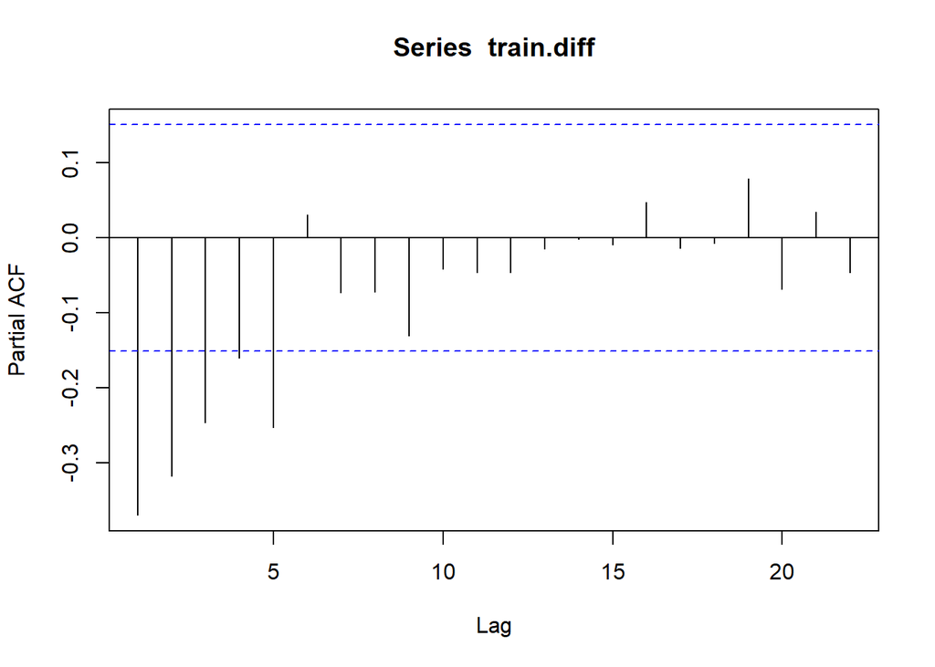

```r
pacf(train.diff)
```

plot PACF cenderung *cuts off* pada lag ke 1, 2, 3, 4, dan 5, sehingga jika plot ACF dianggap tails of, maka model tentatifnya adalah ARIMA(1,1,0) / ARIMA(2,1,0) / ARIMA(3,1,0) / ARIMA(4,1,0) / ARIMA(5,1,0).

##Plot EACF

```r
eacf(train.diff)
```

```
## AR/MA
##   0 1 2 3 4 5 6 7 8 9 10 11 12 13
## 0 x o o o o x o o o o o  o  o  o
## 1 x o o o o o o o o o o  o  o  o
## 2 x o o o o x o o o o o  o  o  o
## 3 x x o o o o o o o o o  o  o  o
## 4 x x o o x o o o o o o  o  o  o
## 5 o x x x x x o o o o o  o  o  o
## 6 x x o x o o o o o o o  o  o  o
## 7 x x o x o o o o o o o  o  o  o
```

model tentatif yang terbentuk adalah ARIMA(0,1,1), ARIMA(0,1,2), ARIMA(0,1,4), ARIMA(1,1,2), ARIMA(1,1,3)